# HOMEWORK 1

Jorge Barcia & Paloma Núñez

```r
# clear environment
rm(list = ls())
```

```r
library(caret)
library(cluster)
library(corrplot)
library(countrycode)
library(dplyr)
library(factoextra)
library(FactoMineR)
library(gganimate)
library(GGally)
library(ggplot2)
library(gifski)
library(mclust)
library(psych)
library(rgl)
library(rmarkdown)
library(rnaturalearth)
library(rworldmap)
library(tidyr)
library(tidyverse)
```

# Data Source

This project uses the [Life Expectancy Data](https://www.kaggle.com/datasets/kumarajarshi/life-expectancy-who)

```r
data = read.csv("Life Expectancy Data.csv")
```

First, let’s check the structure of our data.

```r
str(data)
```

```
## 'data.frame':    2938 obs. of  22 variables:
##  $ Country                        : chr  "Afghanistan" "Afghanistan" "Afghanistan" "Afghanistan" ...
##  $ Year                           : int  2015 2014 2013 2012 2011 2010 2009 2008 2007 2006 ...
##  $ Status                         : chr  "Developing" "Developing" "Developing" "Developing" ...
##  $ Life.expectancy                : num  65 59.9 59.9 59.5 59.2 58.8 58.6 58.1 57.5 57.3 ...
##  $ Adult.Mortality                : int  263 271 268 272 275 279 281 287 295 295 ...
##  $ infant.deaths                  : int  62 64 66 69 71 74 77 80 82 84 ...
##  $ Alcohol                        : num  0.01 0.01 0.01 0.01 0.01 0.01 0.01 0.03 0.02 0.03 ...
##  $ percentage.expenditure         : num  71.3 73.5 73.2 78.2 7.1 ...
##  $ Hepatitis.B                    : int  65 62 64 67 68 66 63 64 63 64 ...
##  $ Measles                        : int  1154 492 430 2787 3013 1989 2861 1599 1141 1990 ...
##  $ BMI                            : num  19.1 18.6 18.1 17.6 17.2 16.7 16.2 15.7 15.2 14.7 ...
##  $ under.five.deaths              : int  83 86 89 93 97 102 106 110 113 116 ...
##  $ Polio                          : int  6 58 62 67 68 66 63 64 63 58 ...
##  $ Total.expenditure              : num  8.16 8.18 8.13 8.52 7.87 9.2 9.42 8.33 6.73 7.43 ...
##  $ Diphtheria                     : int  65 62 64 67 68 66 63 64 63 58 ...
##  $ HIV.AIDS                       : num  0.1 0.1 0.1 0.1 0.1 0.1 0.1 0.1 0.1 0.1 ...
##  $ GDP                            : num  584.3 612.7 631.7 670 63.5 ...
##  $ Population                     : num  33736494 327582 31731688 3696958 2978599 ...
##  $ thinness..1.19.years           : num  17.2 17.5 17.7 17.9 18.2 18.4 18.6 18.8 19 19.2 ...
##  $ thinness.5.9.years             : num  17.3 17.5 17.7 18 18.2 18.4 18.7 18.9 19.1 19.3 ...
##  $ Income.composition.of.resources: num  0.479 0.476 0.47 0.463 0.454 0.448 0.434 0.433 0.415 0.405 ...
##  $ Schooling                      : num  10.1 10 9.9 9.8 9.5 9.2 8.9 8.7 8.4 8.1 ...
```

We can see that we have both numerical and categorical features. We can also see that we need to convert categorical columns to factors.

```r
data = mutate(data, across(c(Country, Status),as.factor))
```

1. **country**:
   - **Description**: The name of the country for which the life expectancy and other health indicators are reported.
2. **year**:
   - **Description**: The year in which the data was recorded.
3. **status**:
   - **Description**: The status of the country in terms of development, indicating whether the country is classified as developed or developing.
4. **life_expectancy**:
   - **Description**: The average life expectancy of people in a country for a given year.
5. **adult_mortality**:
   - **Description**: The number of adult deaths (per 1,000 adults) due to various factors such as disease, accidents, and other causes.
6. **infant_deaths**:
   - **Description**: The number of infant deaths (per 1,000 live births) in a given year.
7. **alcohol**:
   - **Description**: The average amount of alcohol consumed per person (in liters of pure alcohol) in a given year.
8. **percentage_expenditure**:
   - **Description**: The percentage of a country’s GDP spent on healthcare in a given year.
9. **hepatitis_b**:
   - **Description**: The percentage of infants that were vaccinated against Hepatitis B.
10. **measles**:
    - **Description**: The number of reported cases of measles per 1,000 people in a given year.
11. **BMI (Body Mass Index)**:
    - **Description**: The average BMI (Body Mass Index) of the population of a given country, which is used to determine whether individuals are underweight, normal weight, overweight, or obese.
12. **under-five_deaths**:
    - **Description**: The number of deaths per 1,000 live births of children under the age of 5.
13. **polio**:
    - **Description**: The percentage of infants vaccinated against polio in a given year.
14. **total_expenditure**:
    - **Description**: The total amount of health expenditure (in US dollars) per person in a given year.
15. **diphtheria**:
    - **Description**: The percentage of infants vaccinated against Diphtheria in a given year.
16. **hiv_aids**:
    - **Description**: The number of deaths (per 100,000 people) due to HIV/AIDS in a given year.
17. **gdp**:
    - **Description**: The Gross Domestic Product (GDP) of a country per capita in USD.
18. **population**:
    - **Description**: The total population of the country for the given year.
19. **thinness_1_19_years**:
    - **Description**: The percentage of the population between 1 and 19 years old that is considered undernourished or thin (measured by BMI).
20. **thinness_5_9_years**:
    - **Description**: The percentage of the population between 5 and 9 years old that is considered undernourished or thin (measured by BMI).
21. **income_composition_of_resources**:
    - **Description**: A composite index of income composition of resources, which measures the percentage of income that is available for investing in healthcare and other welfare.
22. **schooling**:
    - **Description**: The average number of years of schooling received by people in the country.

## Handling NA Values. Visualizing missing values in each column.

Let’s see a summary of our data to have a first glance of the NA Values and other important information.

```r
summary(data)
```

```
##                 Country          Year             Status     Life.expectancy
##  Afghanistan        :  16   Min.   :2000   Developed : 512   Min.   :36.30
##  Albania            :  16   1st Qu.:2004   Developing:2426   1st Qu.:63.10
##  Algeria            :  16   Median :2008                     Median :72.10
##  Angola             :  16   Mean   :2008                     Mean   :69.22
##  Antigua and Barbuda:  16   3rd Qu.:2012                     3rd Qu.:75.70
##  Argentina          :  16   Max.   :2015                     Max.   :89.00
##  (Other)            :2842                                    NA's   :10
##  Adult.Mortality infant.deaths       Alcohol        percentage.expenditure
##  Min.   :  1.0   Min.   :   0.0   Min.   : 0.0100   Min.   :    0.000
##  1st Qu.: 74.0   1st Qu.:   0.0   1st Qu.: 0.8775   1st Qu.:    4.685
##  Median :144.0   Median :   3.0   Median : 3.7550   Median :   64.913
##  Mean   :164.8   Mean   :  30.3   Mean   : 4.6029   Mean   :  738.251
##  3rd Qu.:228.0   3rd Qu.:  22.0   3rd Qu.: 7.7025   3rd Qu.:  441.534
##  Max.   :723.0   Max.   :1800.0   Max.   :17.8700   Max.   :19479.912
##  NA's   :10                       NA's   :194
##   Hepatitis.B       Measles              BMI        under.five.deaths
##  Min.   : 1.00   Min.   :     0.0   Min.   : 1.00   Min.   :   0.00
##  1st Qu.:77.00   1st Qu.:     0.0   1st Qu.:19.30   1st Qu.:   0.00
##  Median :92.00   Median :    17.0   Median :43.50   Median :   4.00
##  Mean   :80.94   Mean   :  2419.6   Mean   :38.32   Mean   :  42.04
##  3rd Qu.:97.00   3rd Qu.:   360.2   3rd Qu.:56.20   3rd Qu.:  28.00
##  Max.   :99.00   Max.   :212183.0   Max.   :87.30   Max.   :2500.00
##  NA's   :553                        NA's   :34
##      Polio       Total.expenditure   Diphtheria       HIV.AIDS
##  Min.   : 3.00   Min.   : 0.370    Min.   : 2.00   Min.   : 0.100
##  1st Qu.:78.00   1st Qu.: 4.260    1st Qu.:78.00   1st Qu.: 0.100
##  Median :93.00   Median : 5.755    Median :93.00   Median : 0.100
##  Mean   :82.55   Mean   : 5.938    Mean   :82.32   Mean   : 1.742
##  3rd Qu.:97.00   3rd Qu.: 7.492    3rd Qu.:97.00   3rd Qu.: 0.800
##  Max.   :99.00   Max.   :17.600    Max.   :99.00   Max.   :50.600
##  NA's   :19      NA's   :226       NA's   :19
##       GDP              Population        thinness..1.19.years
##  Min.   :     1.68   Min.   :3.400e+01   Min.   : 0.10
##  1st Qu.:   463.94   1st Qu.:1.958e+05   1st Qu.: 1.60
##  Median :  1766.95   Median :1.387e+06   Median : 3.30
##  Mean   :  7483.16   Mean   :1.275e+07   Mean   : 4.84
##  3rd Qu.:  5910.81   3rd Qu.:7.420e+06   3rd Qu.: 7.20
##  Max.   :119172.74   Max.   :1.294e+09   Max.   :27.70
##  NA's   :448         NA's   :652         NA's   :34
##  thinness.5.9.years Income.composition.of.resources   Schooling
##  Min.   : 0.10      Min.   :0.0000                  Min.   : 0.00
##  1st Qu.: 1.50      1st Qu.:0.4930                  1st Qu.:10.10
##  Median : 3.30      Median :0.6770                  Median :12.30
##  Mean   : 4.87      Mean   :0.6276                  Mean   :11.99
##  3rd Qu.: 7.20      3rd Qu.:0.7790                  3rd Qu.:14.30
##  Max.   :28.60      Max.   :0.9480                  Max.   :20.70
##  NA's   :34         NA's   :167                     NA's   :163
```

In order to see clearly the Number NA values and where they are located.

```r
sum(is.na(data))
```

```
## [1] 2563
```

```r
sapply(data, function(x) sum(is.na(x)))
```

```
##                         Country                            Year
##                               0                               0
##                          Status                 Life.expectancy
##                               0                              10
##                 Adult.Mortality                   infant.deaths
##                              10                               0
##                         Alcohol          percentage.expenditure
##                             194                               0
##                     Hepatitis.B                         Measles
##                             553                               0
##                             BMI               under.five.deaths
##                              34                               0
##                           Polio               Total.expenditure
##                              19                             226
##                      Diphtheria                        HIV.AIDS
##                              19                               0
##                             GDP                      Population
##                             448                             652
##            thinness..1.19.years              thinness.5.9.years
##                              34                              34
## Income.composition.of.resources                       Schooling
##                             167                             163
```

Let’s plot this info.

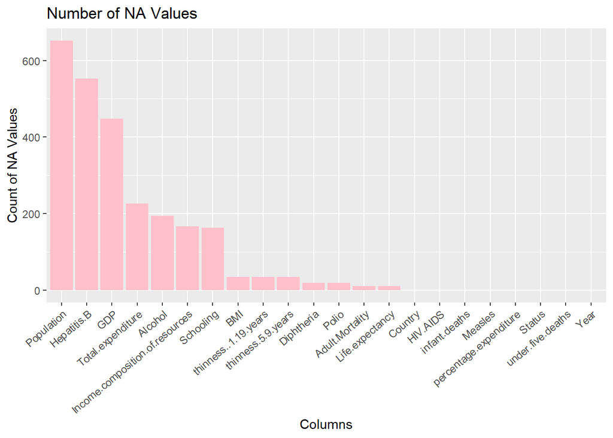

```r
na_counts = sapply(data, function(x) sum(is.na(x)))
aux_df = data.frame(Column = names(na_counts), NA_Count = na_counts)

ggplot(aux_df) +
  aes(x = reorder(Column, -NA_Count), y = NA_Count) +
  geom_bar(stat = "identity", fill = "pink") +
  labs(title = "Number of NA Values", x = "Columns", y = "Count of NA Values") +
  theme(axis.text.x = element_text(angle = 40, hjust = 1))
```

As our missing values are in numerical variables, we will try imputation methods.

```r
# loop through each column
for (col in names(data)) {
  if (is.numeric(data[[col]])) {
    # impute missing values with the column mean
    data[[col]][is.na(data[[col]])] = mean(data[[col]], na.rm = TRUE)
  }
}
```

## Feature Engineering.

```r
# create a life expectancy category based on cut-offs
data$Life_Expectancy_Category = cut(data$Life.expectancy,
                                     breaks = c(0, 50, 70, 100),
                                     labels = c("Low", "Medium", "High"))
# average vaccination rates.
data$AVG_vac = rowMeans(cbind(data$Hepatitis.B,data$Polio,data$Diphtheria))
# we remove individual vacc rates
data$Hepatitis.B = NULL
data$Polio = NULL
data$Diphtheria = NULL
# avoid multicollinearity with BMI
data$thinness..1.19.years = NULL
data$thinness.5.9.years = NULL
```

## Visualization Tools. Exploring distributions and relationships.

`Life Expectancy` map

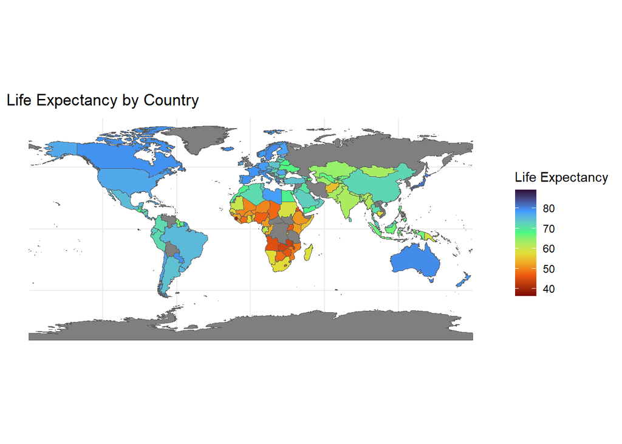

```r
lex_data = select(data,Country, Year, Life.expectancy)
world = ne_countries(scale = "medium", returnclass = "sf")
lex_data = rename(lex_data,name = Country)

world_gdp = left_join(world,lex_data, by = "name")

ggplot(world_gdp) +
  geom_sf(aes(fill = Life.expectancy)) +
  scale_fill_viridis_c(option = "turbo", na.value = "grey50", name = "Life Expectancy",direction = -1) +
  labs(title = "Life Expectancy by Country") +
  theme_minimal()
```

**Correlation analysis**

Using a correlation plot `corrplot`, we visualize the strength and direction of these associations. We also added a heat map to see better what pairs are related.

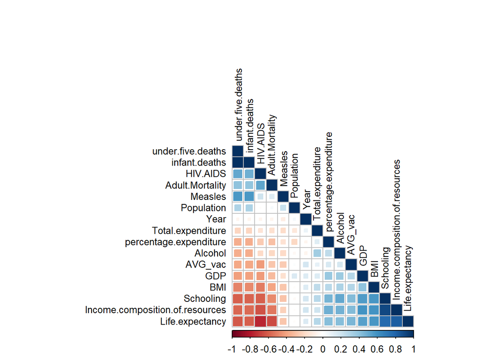

```r
numeric_cols =select(data,-Country, -Status,-Life_Expectancy_Category)

correlations = cor(numeric_cols,method="spearman")
corrplot(correlations, number.cex = .9, method = "square",
         hclust.method = "ward", order = "FPC",
         type = "lower", tl.cex=0.8,tl.col = "black")
```

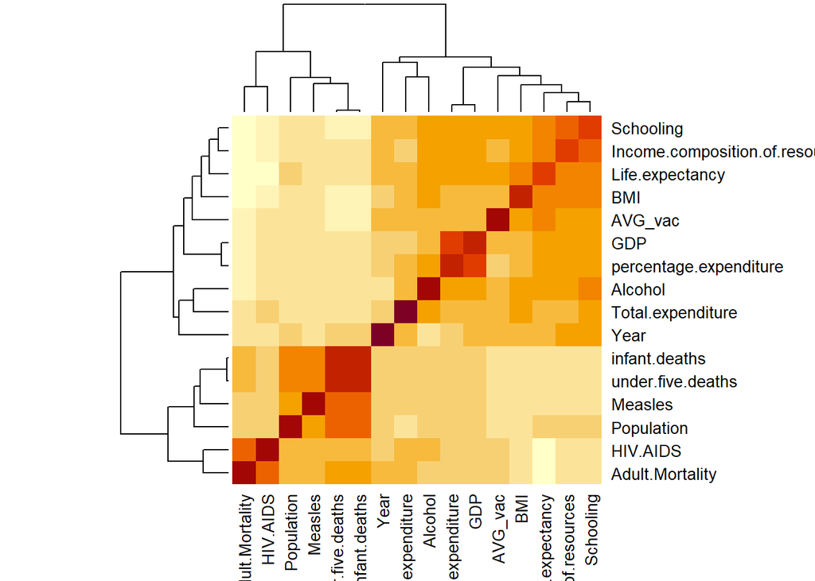

```r
heatmap(cor(numeric_cols))
```

We can see that we have some strong positive correlation along the diagonal and strong negative correlation in the corner.

Let’s see the distribution of `Life Expectancy` for developed and developing countries.

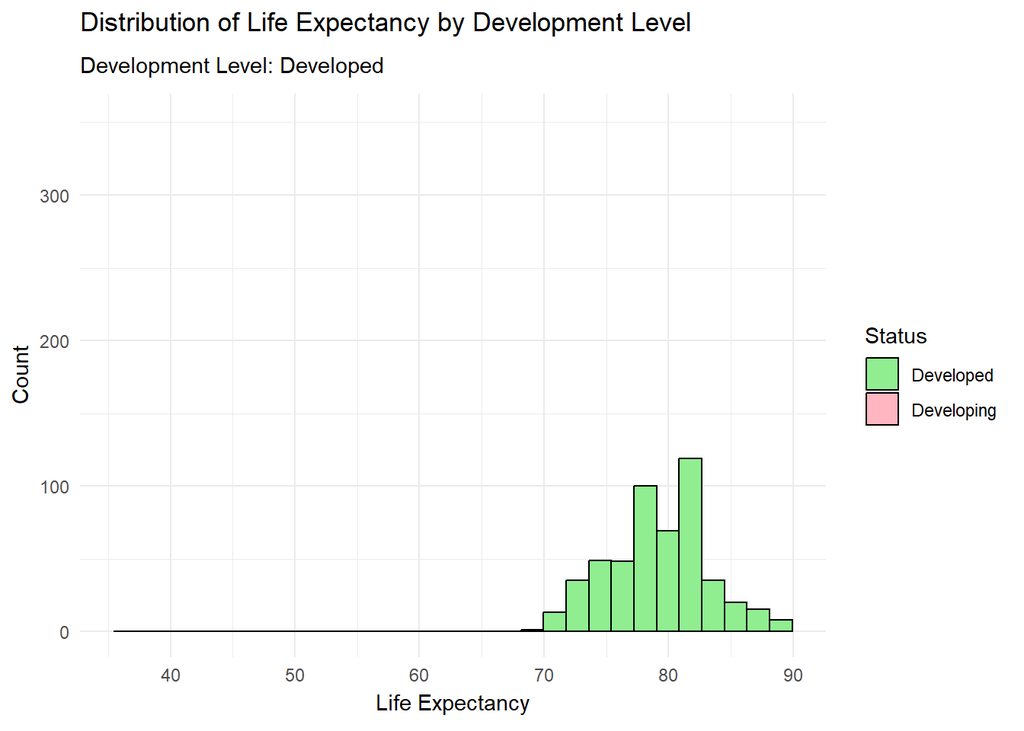

```r
ggplot(data) +
  aes(x = Life.expectancy, fill = Status) +
  geom_histogram(bins = 30, color = "black") +
  labs(title = "Distribution of Life Expectancy by Development Level",
       x = "Life Expectancy", y = "Count") +
  theme_minimal() +
  scale_fill_manual(values = c("lightgreen", "lightpink")) +
  transition_states(Status, transition_length = 0.5, state_length = 1) +
  labs(subtitle = "Development Level: {closest_state}")
```

Now, we will see how is `Schooling` correlated with `Life Expectancy`, and where are the developed countries allocated.

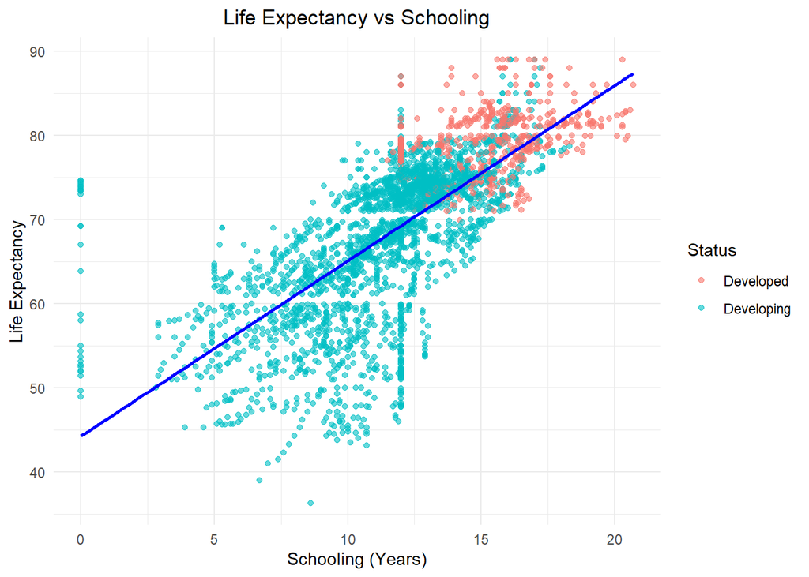

```r
ggplot(data) +
   aes(x = Schooling, y = Life.expectancy, color = Status) +
  geom_point(alpha = 0.6) +
  geom_smooth(method = "lm", color = "blue", se = FALSE) +
  theme_minimal() +
  labs(title = "Life Expectancy vs Schooling",
       x = "Schooling (Years)", y = "Life Expectancy", color = "Status") +
  theme(plot.title = element_text(hjust = 0.5))
```

We’ll see how the `Life Expectancy` has shifted to higher values over the years.

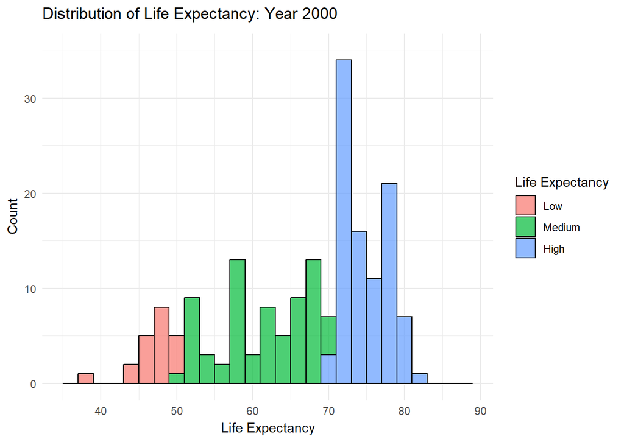

```r
data$Year = as.integer(data$Year)
ggplot(data) +
  aes(x = Life.expectancy, fill = Life_Expectancy_Category) +
  geom_histogram(binwidth = 2, color = "black", alpha = 0.7) +
  labs(title = "Distribution of Life Expectancy: Year {frame_time}",
       x = "Life Expectancy", y = "Count", fill = "Life Expectancy") +
  theme_minimal() +
  transition_time(Year) +
  ease_aes('linear')
```

We can see how the red values slowly disappear, and how the plot shifts to the right.

## Outlier Detection

As we are using a highly reliable dataset, outliers may not necessarily be errors or irrelevant data points. Instead, they might represent meaningful extreme values so we are going to only to erase the outliers that are impossible, for example, the categories that are over 1000 and have +1000 values.

```r
data = data[data$infant.deaths <= 1000, ]
data = data[data$Measles <= 1000, ]
data = data[data$under.five.deaths <= 1000, ]
```

**Using boxplots**

Now, we will check for outliers that could ruin our analysis. Note that we can only have outliers in our numerical features.

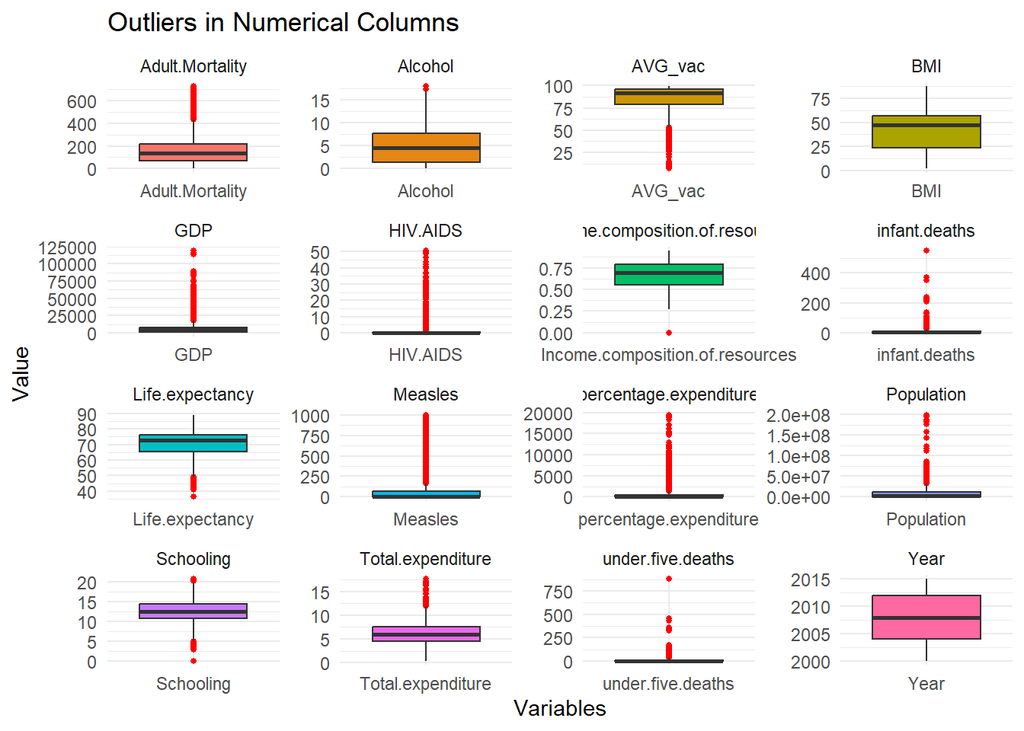

```r
numeric_cols =select(data,-Country, -Status,-Life_Expectancy_Category)
numeric_cols_long = pivot_longer(numeric_cols, cols = everything(), names_to = "Variable", values_to = "Value")
ggplot(numeric_cols_long) +
  aes(x = Variable, y = Value, fill = Variable) +
  geom_boxplot(outlier.color = "red", outlier.size = 1) +
  labs(title = "Outliers in Numerical Columns", x = "Variables", y = "Value") +
  theme_minimal() + theme(axis.text.x = element_text(hjust = 0.5), legend.position = "none")+
  facet_wrap(~ Variable, scales = "free")
```

**Using 3-sigma rule**

```r
detect_outliers_3sigma = function(x) {
  mean_x = mean(x, na.rm = TRUE)
  sd_x = sd(x, na.rm = TRUE)
  lower_bound = mean_x - 3 * sd_x
  upper_bound = mean_x + 3 * sd_x
  return(x < lower_bound | x > upper_bound)
}
outliers = data.frame(
  Year = detect_outliers_3sigma(data$Year),
  Life.expectancy = detect_outliers_3sigma(data$Life.expectancy),
  Adult.Mortality = detect_outliers_3sigma(data$Adult.Mortality),
  infant.deaths = detect_outliers_3sigma(data$infant.deaths),
  Alcohol = detect_outliers_3sigma(data$Alcohol),
  percentage.expenditure = detect_outliers_3sigma(data$percentage.expenditure),
  Measles = detect_outliers_3sigma(data$Measles),
  BMI = detect_outliers_3sigma(data$BMI),
  under.five.deaths = detect_outliers_3sigma(data$under.five.deaths),
  Total.expenditure = detect_outliers_3sigma(data$Total.expenditure),
  HIV.AIDS = detect_outliers_3sigma(data$HIV.AIDS),
  GDP = detect_outliers_3sigma(data$GDP),
  Population = detect_outliers_3sigma(data$Population),
  Income.composition.of.resources = detect_outliers_3sigma(data$Income.composition.of.resources),
  Schooling = detect_outliers_3sigma(data$Schooling),
  AVG_vac = detect_outliers_3sigma(data$AVG_vac)
)
outlier_counts = sapply(outliers, sum)
outlier_counts
```

```
##                            Year                 Life.expectancy
##                               0                               7
##                 Adult.Mortality                   infant.deaths
##                              39                              29
##                         Alcohol          percentage.expenditure
##                               3                              71
##                         Measles                             BMI
##                              88                               0
##               under.five.deaths               Total.expenditure
##                              23                              24
##                        HIV.AIDS                             GDP
##                              57                              66
##                      Population Income.composition.of.resources
##                              35                             117
##                       Schooling                         AVG_vac
##                              28                              45
```

We can not be sure if the data is wrong or a extreme reality so we are going to remove every outlier.

```r
data = data[!apply(outliers, 1, any), ]
```

## PCA

Preprocessing for the PCA.

```r
PCA_data = data
# remove the features we created to do the plots
PCA_data$Life_Expectancy_Category = NULL
# remove non numerical data
PCA_data$Country = NULL
PCA_data$Year = NULL
PCA_data$Status = NULL
```

Perform PCA.

```r
pca = prcomp(PCA_data, scale. = TRUE)

# view PCA summary
summary(pca)
```

```
## Importance of components:
##                          PC1    PC2     PC3     PC4     PC5     PC6     PC7
## Standard deviation     2.391 1.3153 1.17171 1.06183 0.94282 0.91544 0.89074
## Proportion of Variance 0.381 0.1153 0.09153 0.07517 0.05926 0.05587 0.05289
## Cumulative Proportion  0.381 0.4964 0.58789 0.66305 0.72231 0.77818 0.83108
##                            PC8     PC9    PC10    PC11    PC12    PC13    PC14
## Standard deviation     0.79897 0.77951 0.69208 0.65432 0.40150 0.38607 0.24690
## Proportion of Variance 0.04256 0.04051 0.03193 0.02854 0.01075 0.00994 0.00406
## Cumulative Proportion  0.87363 0.91414 0.94607 0.97462 0.98536 0.99530 0.99936
##                           PC15
## Standard deviation     0.09773
## Proportion of Variance 0.00064
## Cumulative Proportion  1.00000
```

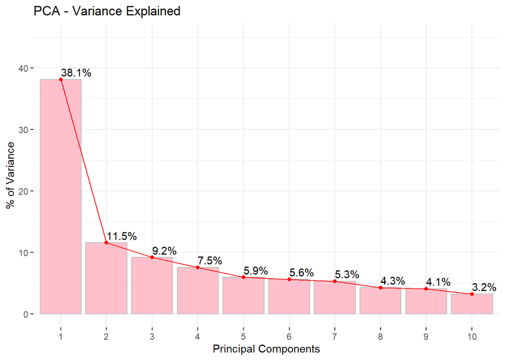

```r
fviz_eig(pca, addlabels = TRUE, ylim = c(0, 45), geom = c("bar", "line"),
         barfill = "pink", barcolor = "grey", linecolor = "red", ncp = 10) +
  labs(title = "PCA - Variance Explained", x = "Principal Components", y = "% of Variance")
```

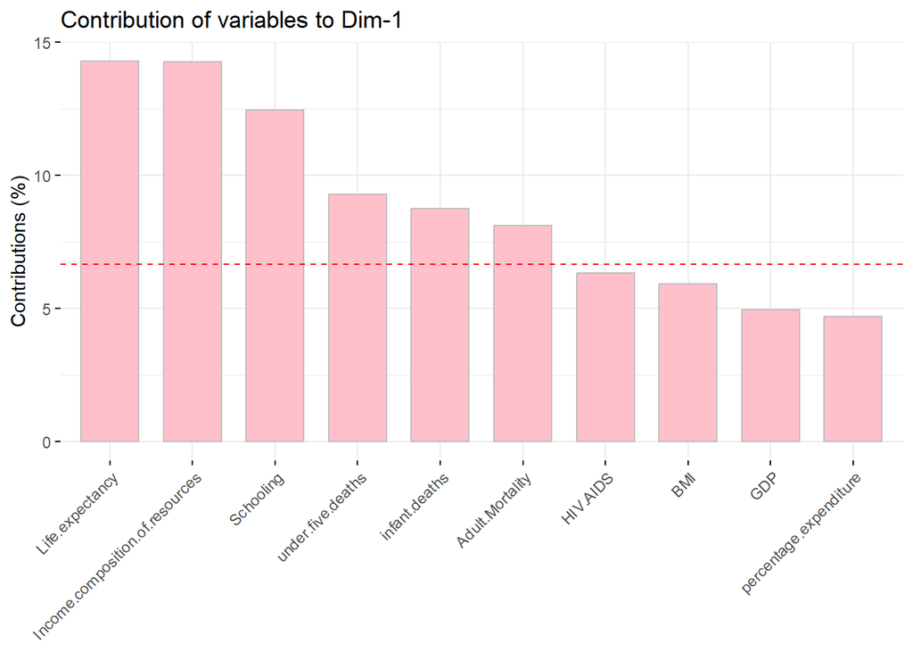

```r
# visualize variable contributions to the first component
fviz_contrib(pca, choice = "var", axes = 1, fill = "pink", color = "grey", top = 10)
```

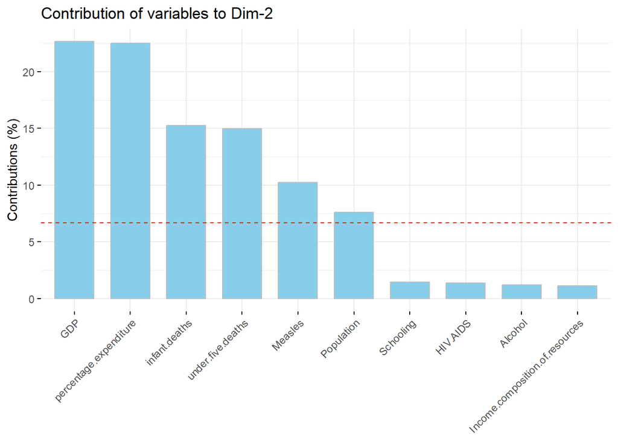

```r
# visualize variable contributions to the second component
fviz_contrib(pca, choice = "var", axes = 2, fill = "skyblue", color = "grey", top = 10)
```

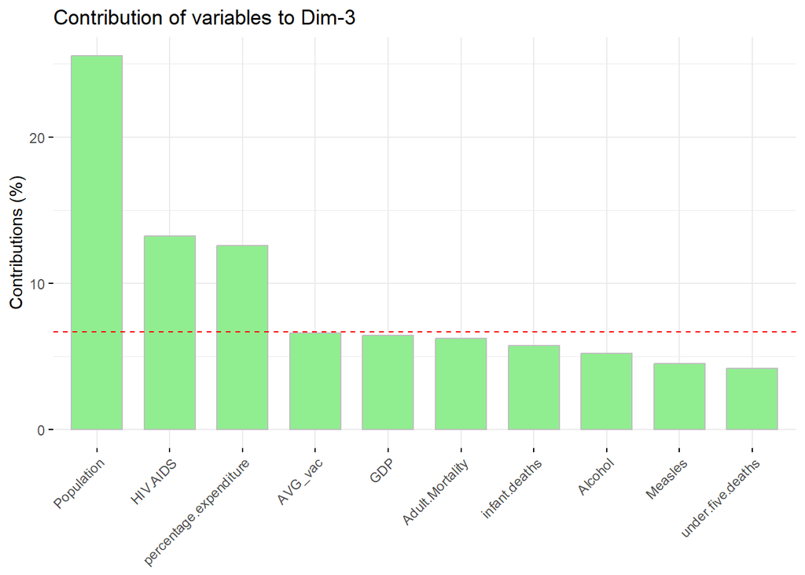

```r
# visualize variable contributions to the second component
fviz_contrib(pca, choice = "var", axes = 3, fill = "lightgreen", color = "grey", top = 10)
```

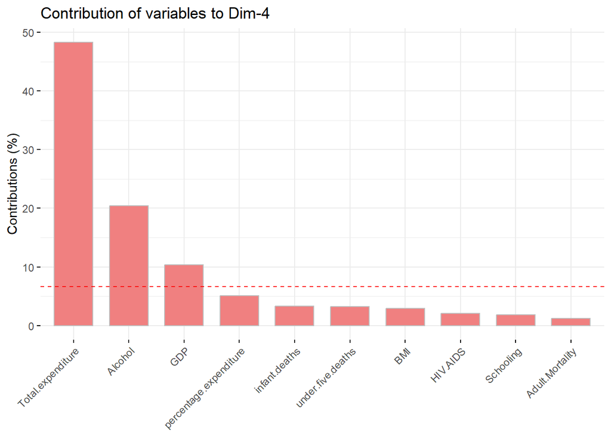

```r
# visualize variable contributions to the second component
fviz_contrib(pca, choice = "var", axes = 4, fill = "lightcoral", color = "grey", top = 10)
```

We can see that PC1 has more variables whose contribution is small, while in PC2, PC3 and PC4, they all have one or two more contributing variables, for example, in PC4 `Total Expenditure` has almost 50% of the contribution.

Note that with 4 components we are able to explain 66% of the variability.

# Rank countries by PCA

PC1

```r
names = data$Country
ordered_indices = order(pca$x[, 1])

best_performers = data.frame(
  Country = data$Country[ordered_indices][(length(names) - 5):length(names)][rev(seq_len(6))],
  Year = data$Year[ordered_indices][(length(names) - 5):length(names)][rev(seq_len(6))]
)

worst_performers = data.frame(
  Country = data$Country[ordered_indices][1:10],
  Year = data$Year[ordered_indices][1:10]
)

print(worst_performers)
```

```
##                     Country Year
## 1                Mozambique 2006
## 2                Mozambique 2007
## 3                     Kenya 2003
## 4                     Kenya 2004
## 5                     Kenya 2005
## 6                      Chad 2007
## 7  Central African Republic 2005
## 8                    Zambia 2007
## 9                      Mali 2003
## 10                     Chad 2010
```

```r
print(best_performers)
```

```
##       Country Year
## 1   Australia 2009
## 2     Finland 2014
## 3 New Zealand 2010
## 4     Iceland 2012
## 5     Finland 2013
## 6     Belgium 2014
```

PC2

```r
names = data$Country
ordered_indices = order(pca$x[, 2])

worst_performers = data.frame(
  Country = data$Country[ordered_indices][(length(names) - 5):length(names)],
  Year = data$Year[ordered_indices][(length(names) - 5):length(names)]
)

best_performers = data.frame(
  Country = data$Country[ordered_indices][1:10],
  Year = data$Year[ordered_indices][1:10]
)

print(worst_performers)
```

```
##           Country Year
## 1        Kiribati 2010
## 2        Kiribati 2011
## 3 Solomon Islands 2014
## 4 Solomon Islands 2013
## 5        Djibouti 2014
## 6 Solomon Islands 2000
```

```r
print(best_performers)
```

```
##        Country Year
## 1       France 2008
## 2       France 2013
## 3        Japan 2006
## 4      Ireland 2012
## 5      Ireland 2010
## 6        Spain 2006
## 7      Belgium 2008
## 8    Australia 2009
## 9  Netherlands 2005
## 10  Mozambique 2006
```

Let’s now visualize the top-10 Countries contributions to first component:

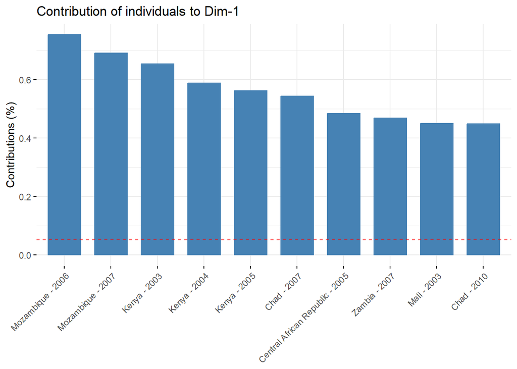

```r
names_order = names[order(get_pca_ind(pca)$contrib[,1],decreasing=T)]
combined_labels = paste(names_order, data$Year[order(get_pca_ind(pca)$contrib[, 1], decreasing = TRUE)], sep = " - ")

fviz_contrib(pca, choice = "ind", axes = 1, top=10)+scale_x_discrete(labels=combined_labels)
```

From this we can see that the worst Countries are the ones that are contributing more to the total Variance, and those contributions are not equally distributed through the observations.

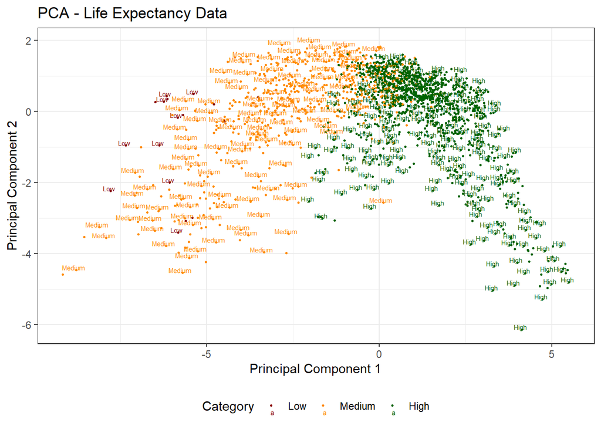

```r
# 2D Data Frame
pca_plot_data = data.frame(
  PC1 = -pca$x[, 1],
  PC2 = pca$x[, 2],
  Category = data$Life_Expectancy_Category
)
# 2D plot
ggplot(pca_plot_data, aes(x = -PC1, y = PC2, label = Category, color = Category)) +
  geom_point(size = 0.5) +
  labs(title = "PCA - Life Expectancy Data", x = "Principal Component 1", y = "Principal Component 2") +
  theme_bw() +
  scale_color_manual(values = c("darkred", "darkorange","darkgreen")) +
  theme(legend.position = "bottom") +
  geom_text(size = 2, hjust = 0.6, vjust = 0, check_overlap = TRUE)
```

With PC1 and PC2 we can see that we may be able to predict it. Now, we add PC3 and PC4 (as size) to see if this helps.

```r
# 4D data frame
pca_3d_data = data.frame(
  PC1 = pca$x[, 1],
  PC2 = pca$x[, 2],
  PC3 = pca$x[, 3],
  PC4 = pca$x[, 4],
  Category = data$Life_Expectancy_Category
)
# color
category_colors = ifelse(pca_3d_data$Category == "High", "darkgreen",
                          ifelse(pca_3d_data$Category == "Medium", "darkorange", "darkred"))

# size
pca_3d_data$PC4_normalized = scales::rescale(pca_3d_data$PC4)
# 4D plot
open3d()
```

```
## wgl
##   1
```

```r
plot3d(
  x = pca_3d_data$PC1,
  y = pca_3d_data$PC2,
  z = pca_3d_data$PC3,
  col = category_colors,
  type = "s",
  size = pca_3d_data$PC4_normalized * 5,
  xlab = "PC1",
  ylab = "PC2",
  zlab = "PC3",
  main = "3D PCA Plot of Life Expectancy Data"
)
legend3d("topright", legend = c("Low", "Medium","High"),
         col = c("darkred", "darkorange","darkgreen"), pch = 16, cex = 1)
# for rendering in html format
rglwidget()
```

[interactive chart not shown]

## Factor Analysis

Factor analysis is a statistical method used to identify underlying relationships between variables by grouping them into “factors,” which represent shared patterns making it useful for exploring and modeling complex datasets.

FA data preproccesing.

```r
fa_data = data
# remove the features we created
fa_data$Life_Expectancy_Category = NULL
# remove non numerical data and unimportant data for the FA
fa_data$Country = NULL
fa_data$Year = NULL
fa_data$Status = NULL
# check for Multicollinearity
cor_matrix = cor(fa_data)
high_corr = findCorrelation(cor_matrix, cutoff = 0.9)
fa_data = fa_data[, -high_corr]
```

Let’s check the scree plot:

```r
screepl = fa.parallel(fa_data,fm = "ml",fa = "fa")
```

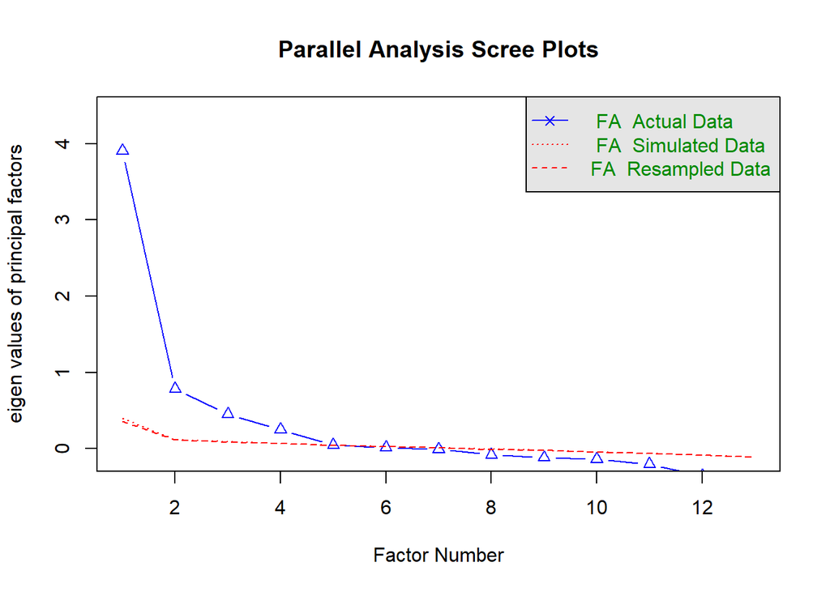

```
## Parallel analysis suggests that the number of factors =  4  and the number of components =  NA
```

We perform FA and plot the loadings and Uniqueness to better understand what we have.

```r
fa_result = factanal(fa_data, factors = 6, rotation="varimax", scores="Bartlett", lower = 0.01)

# save this for conclusions of clusters
faRes = fa_result

fa_result
```

```
##
## Call:
## factanal(x = fa_data, factors = 6, scores = "Bartlett", rotation = "varimax",     lower = 0.01)
##
## Uniquenesses:
##        Life.expectancy        Adult.Mortality          infant.deaths
##                  0.096                  0.441                  0.010
##                Alcohol percentage.expenditure                Measles
##                  0.627                  0.010                  0.864
##                    BMI      Total.expenditure               HIV.AIDS
##                  0.694                  0.010                  0.461
##                    GDP             Population              Schooling
##                  0.212                  0.739                  0.200
##                AVG_vac
##                  0.797
##
## Loadings:
##                        Factor1 Factor2 Factor3 Factor4 Factor5 Factor6
## Life.expectancy         0.809   0.231   0.385  -0.206
## Adult.Mortality        -0.713  -0.146  -0.125   0.106
## infant.deaths          -0.342  -0.113  -0.173   0.890           0.190
## Alcohol                 0.119   0.171   0.517  -0.171   0.177
## percentage.expenditure  0.132   0.957   0.175                  -0.140
## Measles                -0.112          -0.101   0.315
## BMI                     0.413           0.322  -0.138
## Total.expenditure                       0.188           0.967
## HIV.AIDS               -0.719                   0.134
## GDP                     0.168   0.844   0.151                   0.145
## Population                                      0.201           0.462
## Schooling               0.491   0.257   0.677  -0.168
## AVG_vac                 0.345           0.148  -0.170           0.168
##
##                Factor1 Factor2 Factor3 Factor4 Factor5 Factor6
## SS loadings      2.412   1.821   1.144   1.117   1.000   0.344
## Proportion Var   0.186   0.140   0.088   0.086   0.077   0.026
## Cumulative Var   0.186   0.326   0.414   0.500   0.577   0.603
##
## Test of the hypothesis that 6 factors are sufficient.
## The chi square statistic is 40.9 on 15 degrees of freedom.
## The p-value is 0.000331
```

```r
cbind(fa_result$loadings, "Uniqueness" = fa_result$uniquenesses)
```

```
##                            Factor1      Factor2      Factor3     Factor4
## Life.expectancy         0.80896194  0.231242380  0.385340481 -0.20638626
## Adult.Mortality        -0.71258683 -0.146013515 -0.125473057  0.10573112
## infant.deaths          -0.34152288 -0.112554093 -0.172901631  0.89039130
## Alcohol                 0.11863738  0.171455053  0.517089041 -0.17070048
## percentage.expenditure  0.13156147  0.957107509  0.174727581  0.01229828
## Measles                -0.11179017  0.016558006 -0.100762620  0.31549967
## BMI                     0.41264540  0.064906620  0.321552399 -0.13817477
## Total.expenditure       0.09588658  0.054577822  0.187593143 -0.05369836
## HIV.AIDS               -0.71943977 -0.042871596 -0.010855506  0.13408321
## GDP                     0.16779342  0.843718849  0.151255271 -0.06674071
## Population              0.07039802  0.003663567  0.002533388  0.20143114
## Schooling               0.49054263  0.256963052  0.676953049 -0.16845784
## AVG_vac                 0.34480305  0.031316343  0.148285748 -0.16951195
##                             Factor5     Factor6 Uniqueness
## Life.expectancy         0.068618006  0.02421187 0.09573043
## Adult.Mortality        -0.037492777  0.03881537 0.44106539
## infant.deaths           0.044819255  0.18972136 0.01000000
## Alcohol                 0.177108731 -0.03631250 0.62732084
## percentage.expenditure  0.079099541 -0.14035352 0.01000000
## Measles                -0.059298454  0.09846609 0.86432018
## BMI                     0.069847484  0.06393094 0.69405775
## Total.expenditure       0.967300896 -0.06388591 0.01000000
## HIV.AIDS               -0.011147013 -0.04020015 0.46072983
## GDP                    -0.001583981  0.14476315 0.21169307
## Population             -0.045034467  0.46184031 0.73912531
## Schooling               0.061683042  0.05504719 0.19985951
## AVG_vac                 0.063703569  0.16768330 0.79723850
```

There are some variables that seem to be behave independently on the dataset like `Population`and `Measle` among others, as even using 6 factors their uniqueness is still high. We are going to try again without these variables.

```r
fa_data$AVG_vac = NULL
fa_data$Population = NULL
fa_data$Total.expenditure = NULL
fa_data$Measles = NULL

fa_result2 = factanal(fa_data, factors = 3, rotation="varimax", scores="Bartlett", lower = 0.01)

fa_result2
```

```
##
## Call:
## factanal(x = fa_data, factors = 3, scores = "Bartlett", rotation = "varimax",     lower = 0.01)
##
## Uniquenesses:
##        Life.expectancy        Adult.Mortality          infant.deaths
##                  0.086                  0.448                  0.672
##                Alcohol percentage.expenditure                    BMI
##                  0.621                  0.010                  0.696
##               HIV.AIDS                    GDP              Schooling
##                  0.464                  0.289                  0.240
##
## Loadings:
##                        Factor1 Factor2 Factor3
## Life.expectancy         0.804   0.232   0.462
## Adult.Mortality        -0.705  -0.162  -0.168
## infant.deaths          -0.452          -0.341
## Alcohol                         0.174   0.583
## percentage.expenditure  0.104   0.972   0.184
## BMI                     0.406           0.368
## HIV.AIDS               -0.728
## GDP                     0.163   0.805   0.191
## Schooling               0.471   0.256   0.688
##
##                Factor1 Factor2 Factor3
## SS loadings      2.310   1.783   1.381
## Proportion Var   0.257   0.198   0.153
## Cumulative Var   0.257   0.455   0.608
##
## Test of the hypothesis that 3 factors are sufficient.
## The chi square statistic is 45.09 on 12 degrees of freedom.
## The p-value is 9.94e-06
```

```r
cbind(fa_result2$loadings, "Uniqueness" = fa_result2$uniquenesses)
```

```
##                           Factor1     Factor2     Factor3 Uniqueness
## Life.expectancy         0.8038665  0.23247115  0.46220420 0.08612296
## Adult.Mortality        -0.7049175 -0.16238438 -0.16821382 0.44842564
## infant.deaths          -0.4517655 -0.08770430 -0.34140249 0.67166028
## Alcohol                 0.0963441  0.17420551  0.58270596 0.62082093
## percentage.expenditure  0.1039540  0.97230916  0.18387498 0.01000000
## BMI                     0.4061382  0.05939326  0.36754155 0.69642958
## HIV.AIDS               -0.7276616 -0.04453875 -0.06737523 0.46398698
## GDP                     0.1630150  0.80503338  0.19063082 0.28901100
## Schooling               0.4708672  0.25566715  0.68798625 0.23959278
```

We now see that without these variables, we get better proportion of variance explained (61%) with less Factors 3.

## Clustering tools

Some Data preprocessing.

```r
Category = data$Life_Expectancy_Category
# the clusters are at their best when the distances to the centroids is minimal
X = select(data,-Country,-Year,-Status,-Life_Expectancy_Category)
k = 2
X = scale(X)
```

We are going to start by determining the optimal number of clusters.

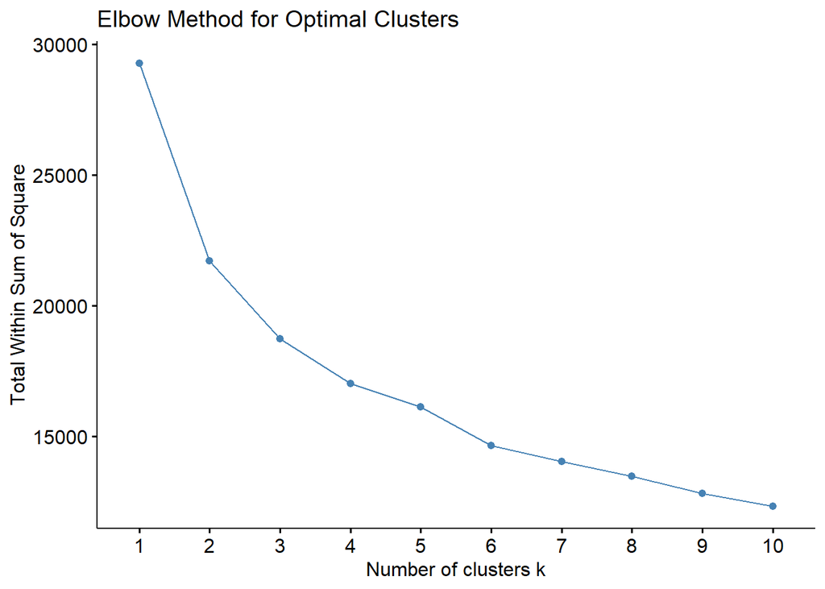

```r
# elbow Method
fviz_nbclust(X, kmeans, method = "wss") +
  ggtitle("Elbow Method for Optimal Clusters")
```

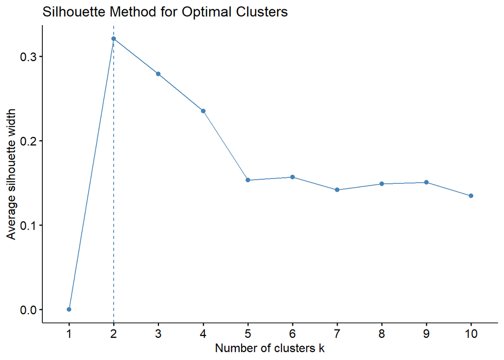

```r
# the Elbow Method do not leave it completely clear so let use other
# silhouette Method
fviz_nbclust(X, kmeans, method = "silhouette") +
  ggtitle("Silhouette Method for Optimal Clusters")
```

Perform K-means Clustering with 2 Clusters.

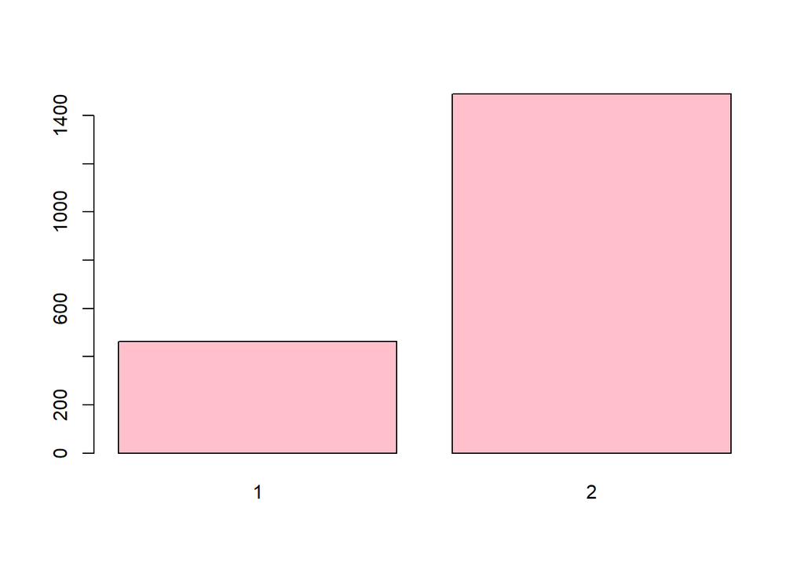

```r
set.seed(123)
kmeans_result = kmeans(X, centers = k, nstart = 1000)

cluster = kmeans_result$cluster
barplot(table(cluster), col="pink")
```

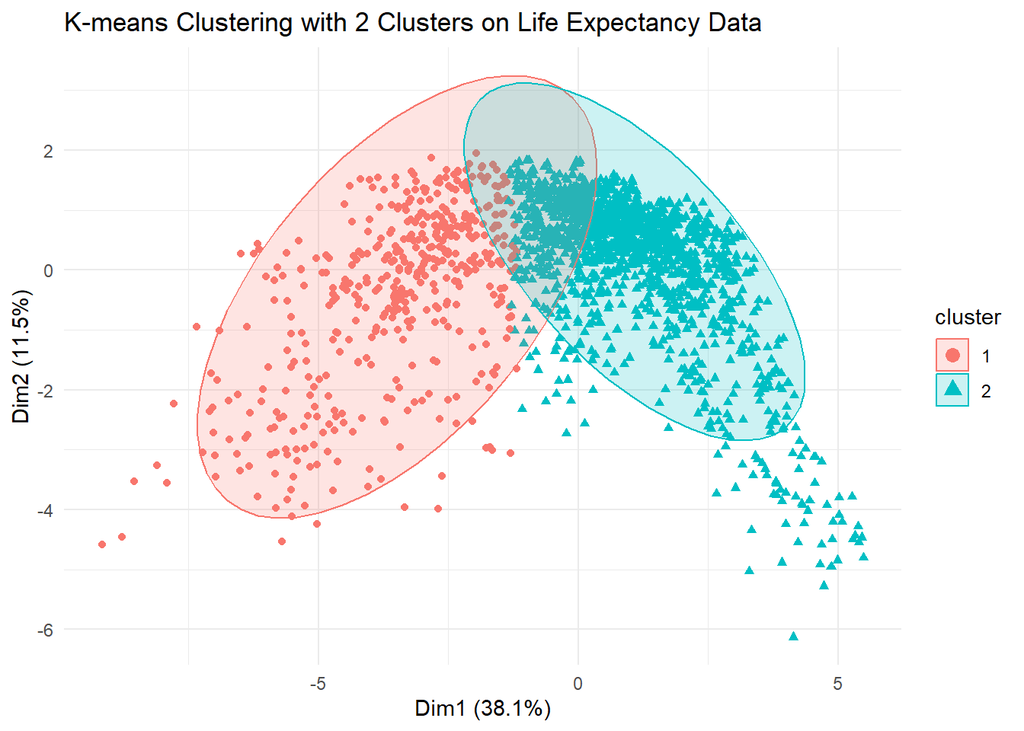

```r
# clusplot without names as they are unreadable
fviz_cluster(kmeans_result, data = X, geom = "point", ellipse.type = "norm") +
  labs(title = "K-means Clustering with 2 Clusters on Life Expectancy Data") +
  theme_minimal()
```

```r
fit.kmeans = eclust(X, "kmeans", stand=TRUE, k=k)
```

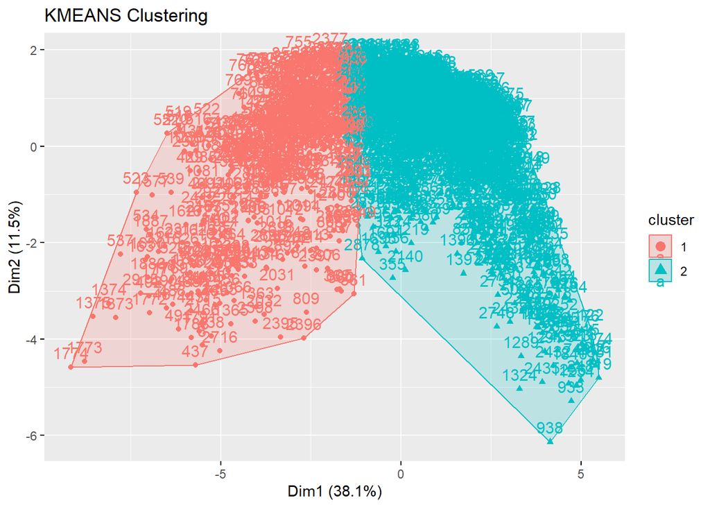

Let’s check the quality of our clusters.

```
##   cluster size ave.sil.width
## 1       1  462          0.15
## 2       2 1490          0.37
```

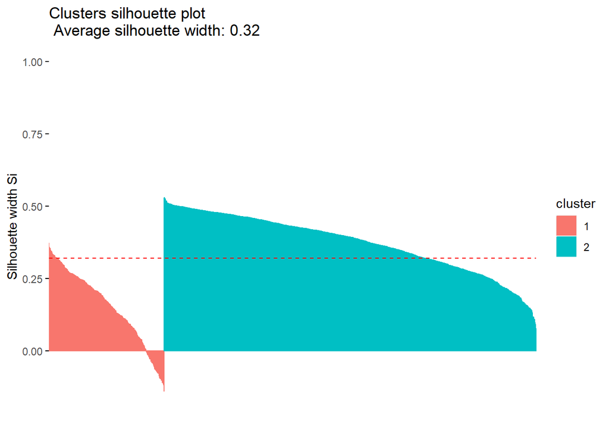

```r
fviz_silhouette(fit.kmeans)
```

Now, we see wwere are this clusters allocated in our original dataset to retrieve some knowledge.

```r
# add cluster data
data$Cluster = kmeans_result$cluster

# calculate summary statistics for each cluster
cluster_summary = aggregate(. ~ Cluster, data = data, FUN = mean, na.rm = TRUE)
cluster_summary = select(cluster_summary,-Country,-Year,-Status,-Life_Expectancy_Category)
print(cluster_summary)
```

```
##   Cluster Life.expectancy Adult.Mortality infant.deaths  Alcohol
## 1       1        60.48615        247.3874     23.608225 2.508420
## 2       2        74.69188        112.7190      2.874497 5.647985
##   percentage.expenditure   Measles      BMI under.five.deaths Total.expenditure
## 1               80.86411 119.13853 23.35915         34.244589          5.314955
## 2              708.19436  37.01208 47.30191          3.409396          6.195244
##    HIV.AIDS      GDP Population Income.composition.of.resources Schooling
## 1 2.9759740 2373.536    7078254                       0.4898264  9.326157
## 2 0.1926174 8032.038    6547167                       0.7422122 13.708918
##   AVG_vac
## 1 74.9814
## 2 89.7022
```

From this table, we see the differences between the mean values of countries in cluster 1 and 2. In the clustering analysis of the Life Expectancy dataset, `Cluster 2` shows higher averages for positive indicators such as `life expectancy, GDP, and schooling`, suggesting that countries in this cluster tend to have better socioeconomic and health conditions. Conversely, negative indicators such as `adult mortality, infant deaths, and HIV/AIDS prevalence` are lower in Cluster 2, indicating better healthcare outcomes. In `Cluster 1`, these positive indicators are lower on average, while negative health indicators are higher, implying that countries in this cluster may face more significant health and economic challenges.

As one of our crucial insights, what we have realized in this step is that even that the means of `Measles` are far apart one group from an other. The FA did not show important linear relations and seemed to be independent. After investigating this phenomenon, we arrive to the conclusion that Measles incidence rates are more influenced by factors like periodic vaccination campaigns or public health policies, rather than forming a predictable, linear relationship with socioeconomic indicators.

This is why Factor Analysis did not identify Measles as strongly associated with any particular factor, even though clusters reveal distinct differences in Measles rates.

Let’s confirm our theory by checking what are the most influential observations.

In order to check our theory, we need to measure the influence of each data point for this objective. We are using Cook’s distance

```r
factor_scores = faRes$scores
# make linear regression with the Scores
model = lm(data$Measles ~ factor_scores)
# calculate distance
cooksd = cooks.distance(model)
# sort
ordered_cooksd = sort(cooksd, decreasing = TRUE)
# top 10
top_10_influential_indices = order(cooksd, decreasing = TRUE)[1:10]

# select country and year
top_10_countries_and_years = data[top_10_influential_indices, c("Country", "Year")]

print(top_10_countries_and_years)
```

```
##                       Country Year
## 938                    France 2008
## 1324                    Japan 2006
## 2311             Sierra Leone 2002
## 2915                   Zambia 2007
## 437             Côte d'Ivoire 2011
## 245                   Belgium 2011
## 523  Central African Republic 2005
## 2534              Switzerland 2003
## 809                     Egypt 2009
## 491                  Cameroon 2005
```

We are ordering them using Cook’s Distance so we can get an idea of the most influential observations. Observe that some countries like France or Japan, that are placed in the cluster of high developed, are among this list. This confirms our theory that Measles are not following the expected linear relation